# **Project 2**, APS1070 Fall 2023

## **Part 3: Multiple feature model with one Gaussian distribution: [1 Marks]**

This part is similar to Part 2, but we will pick multiple features and **visually** set the number of components.

a. 2D plot:

1. Pick two features (say, f1 and f2).
2. Scatter plot (plt.scatter) those features on a figure (f1 on the x-axis and f2 on the y-axis).
3. Color the data points based on their class (not-fraud blue and fraud red).
4. Based on your plots, decide how many Gaussian components (`n_components`) you need to fit the data (focus on valid transactions). Explain. **[0.25]**
5. Fit your Gaussian model on all the data points.
6. Compute AUC on both training and validation sets
7. Pick 3 new pairs of features and repeat steps 2 to 6. **[0.25]**
8. For each pair, find a threshold to maximize your validation set F1 Score.**[0.25]**
9. For each pair, plot a figure similar to step 3 and put a circle around outliers based on your threshold (use the code of the similar figure in the tutorial) **[0.25]**

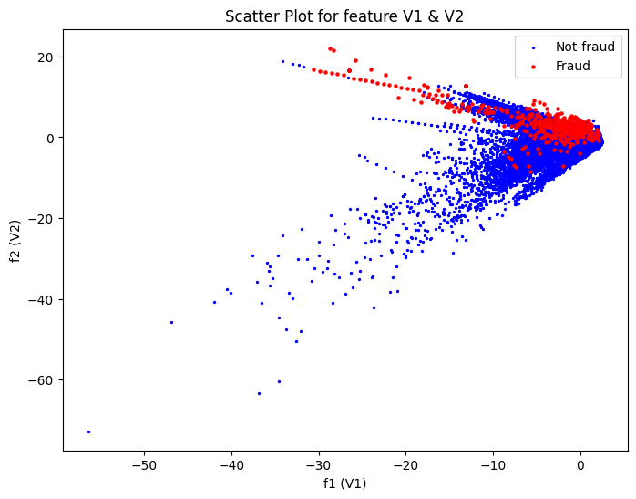

```python
import matplotlib.pyplot as plt
import numpy as np

# Extract v1 and v2 from dataset as f1 f2
f1 = df['V1']
f2 = df['V2']

plt.figure(figsize=(8,6))

# Create scatter plot according to class
# To non-fraud transaction（Class=0), use blue
plt.scatter(f1[df['Class'] == 0], f2[df['Class'] == 0], color='blue', label='Not-fraud', s=2)
# To fraud transaction (class=1), use red
plt.scatter(f1[df['Class'] == 1], f2[df['Class'] == 1], color='red', label='Fraud', s=5)

# set up labels
plt.title('Scatter Plot for feature V1 & V2')
plt.xlabel('f1 (V1)')
plt.ylabel('f2 (V2)')
plt.legend()
plt.show()
```

**For the scatter plot with feature v1 and v2, There are more than one main clusters/peaks with centerd blue points (non-fraud transaction. The first non-fraud cluster is around center of fraud transaction. The second cluster is at the left downward side. The distribution of red dots (fraud transactions) looks like a cluster with some linear extensions. In this case, I think it requires at least two components.**

```python
f1_train = X_train['V1'].values.reshape(-1, 1)
f2_train = X_train['V2'].values.reshape(-1, 1)
f1_val = X_val['V1'].values.reshape(-1, 1)
f2_val = X_val['V2'].values.reshape(-1, 1)

train_v1v2 = np.hstack((f1_train, f2_train))
val_v1v2 = np.hstack((f1_val, f2_val))

gm_v1v2 = GaussianMixture(n_components = 2, covariance_type = 'full', random_state=0)
gm_v1v2.fit(train_v1v2)

score_train_v1v2=gm_v1v2.score_samples(train_v1v2)
score_val_v1v2=gm_v1v2.score_samples(val_v1v2)

auc_train_v1v2 = roc_auc_score(y_train, -score_train_v1v2)
auc_val_v1v2 = roc_auc_score(y_val, -score_val_v1v2)

print(f'AUC score for training set v1v2 is {auc_train_v1v2}\nAUC score for validation set v1v2 is {auc_val_v1v2}')
```

```
AUC score for training set v1v2 is 0.8805474329848777
AUC score for validation set v1v2 is 0.861260934041286
```

```python
thresholds_v1v2 = np.linspace(min(score_val_v1v2), max(score_val_v1v2), 200) # Generate more threshold value
f1_scores_v1v2 = []
for threshold in thresholds_v1v2:
  f1 = f1_score(y_val, score_val_v1v2 < threshold)
  f1_scores_v1v2.append(f1)

# Return the best threshold index by locating highest f1_score index
best_threshold_v1v2 = thresholds_v1v2[np.argmax(f1_scores_v1v2)]
print(f'Best F1 score: {max(f1_scores_v1v2)} at threshold: {best_threshold_v1v2}')
```

```
Best F1 score: 0.08450704225352113 at threshold: -24.99682768039014
```

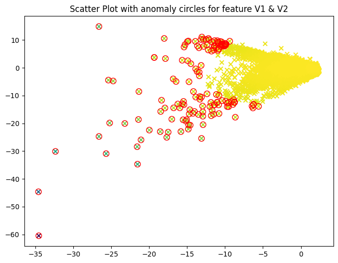

```python
# Create scatter plot to highlight on the scatter plot all points that are below threshold
plt.figure(figsize=(8,6))
plt.scatter(val_v1v2[:,0], val_v1v2[:,1], marker="x", c=score_val_v1v2, cmap='viridis');

# Circling of anomalies
outliers = np.nonzero(score_val_v1v2 < best_threshold_v1v2)[0] # indices for which scores are below the threshold
plt.scatter(val_v1v2[outliers, 0], val_v1v2[outliers, 1], marker="o", facecolor="none", edgecolor="r", s=70)
plt.title('Scatter Plot with anomaly circles for feature V1 & V2')
```

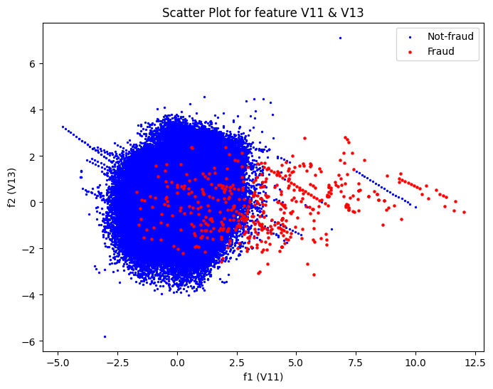

```python
import matplotlib.pyplot as plt
import numpy as np

# Extract v11 and v13 from dataset as f1 f2
f1 = df['V11']
f2 = df['V13']

plt.figure(figsize=(8,6))

# Create scatter plot according to class
# To non-fraud transaction（Class=0), use blue
plt.scatter(f1[df['Class'] == 0], f2[df['Class'] == 0], color='blue', label='Not-fraud', s=2)
# To fraud transaction (class=1), use red
plt.scatter(f1[df['Class'] == 1], f2[df['Class'] == 1], color='red', label='Fraud', s=5)

# set up labels
plt.title('Scatter Plot for feature V11 & V13')
plt.xlabel('f1 (V11)')
plt.ylabel('f2 (V13)')
plt.legend()
plt.show()
```

```python
f1_train = X_train['V11'].values.reshape(-1, 1)
f2_train = X_train['V13'].values.reshape(-1, 1)
f1_val = X_val['V11'].values.reshape(-1, 1)
f2_val = X_val['V13'].values.reshape(-1, 1)

train_v11v13 = np.hstack((f1_train, f2_train))
val_v11v13 = np.hstack((f1_val, f2_val))

gm_v11v13 = GaussianMixture(n_components = 3, covariance_type = 'full', random_state=0)
gm_v11v13.fit(train_v11v13)

score_train_v11v13=gm_v11v13.score_samples(train_v11v13)
score_val_v11v13=gm_v11v13.score_samples(val_v11v13)

auc_train_v11v13 = roc_auc_score(y_train, -score_train_v11v13)
auc_val_v11v13 = roc_auc_score(y_val, -score_val_v11v13)

print(f'AUC score for training set v1v2 is {auc_train_v11v13}\nAUC score for validation set v1v2 is {auc_val_v11v13}')
```

[output not shown]

```python
thresholds_v11v13 = np.linspace(min(score_val_v11v13), max(score_val_v11v13), 200) # Generate more threshold value
f1_scores_v11v13 = []
for threshold in thresholds_v11v13:
  f1 = f1_score(y_val, score_val_v11v13 < threshold)
  f1_scores_v11v13.append(f1)

# Return the best threshold index by locating highest f1_score index
best_threshold_v11v13 = thresholds_v11v13[np.argmax(f1_scores_v11v13)]
print(f'Best F1 score: {max(f1_scores_v11v13)} at threshold: {best_threshold_v11v13}')
```

```
Best F1 score: 0.4920634920634921 at threshold: -9.894059033515305
```

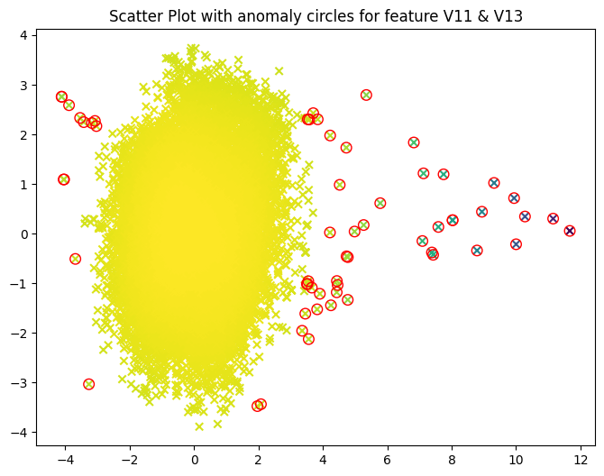

```python
# Create scatter plot to highlight on the scatter plot all points that are below threshold
plt.figure(figsize=(8,6))
plt.scatter(val_v11v13[:,0], val_v11v13[:,1], marker="x", c=score_val_v11v13, cmap='viridis');

# Circling of anomalies
outliers = np.nonzero(score_val_v11v13 < best_threshold_v11v13)[0] # indices for which scores are below the threshold
plt.scatter(val_v11v13[outliers, 0], val_v11v13[outliers, 1], marker="o", facecolor="none", edgecolor="r", s=70)
plt.title('Scatter Plot with anomaly circles for feature V11 & V13')
```

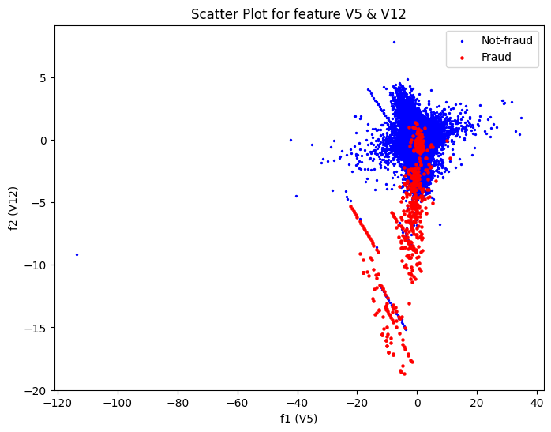

```python
# Extract v11 and v13 from dataset as f1 f2
f1 = df['V5']
f2 = df['V12']

plt.figure(figsize=(8,6))

# Create scatter plot according to class
# To non-fraud transaction（Class=0), use blue
plt.scatter(f1[df['Class'] == 0], f2[df['Class'] == 0], color='blue', label='Not-fraud', s=2)
# To fraud transaction (class=1), use red
plt.scatter(f1[df['Class'] == 1], f2[df['Class'] == 1], color='red', label='Fraud', s=5)

# set up labels
plt.title('Scatter Plot for feature V5 & V12')
plt.xlabel('f1 (V5)')
plt.ylabel('f2 (V12)')
plt.legend()
plt.show()
```

**From the feature v5 & v12 scatter plot above, there are two to three major clusters for blue data points. The red points (fraud transaction) are partially located in the center of blue clusters, while the others are clustered below. Based on the plot, I think n_component should be 4 to fit the model.**

```python
f1_train = X_train['V5'].values.reshape(-1, 1)
f2_train = X_train['V12'].values.reshape(-1, 1)
f1_val = X_val['V5'].values.reshape(-1, 1)
f2_val = X_val['V12'].values.reshape(-1, 1)

train_v5v12 = np.hstack((f1_train, f2_train))
val_v5v12 = np.hstack((f1_val, f2_val))

gm_v5v12 = GaussianMixture(n_components = 4, covariance_type = 'full', random_state=0)
gm_v5v12.fit(train_v5v12)

score_train_v5v12=gm_v5v12.score_samples(train_v5v12)
score_val_v5v12=gm_v5v12.score_samples(val_v5v12)

auc_train_v5v12 = roc_auc_score(y_train, -score_train_v5v12)
auc_val_v5v12 = roc_auc_score(y_val, -score_val_v5v12)

print(f'AUC score for training set v1v2 is {auc_train_v5v12}\nAUC score for validation set v1v2 is {auc_val_v5v12}')
```

[output not shown]

```python
thresholds_v5v12 = np.linspace(min(score_val_v5v12), max(score_val_v5v12), 200) # Generate more threshold value
f1_scores_v5v12 = []
for threshold in thresholds_v5v12:
  f1 = f1_score(y_val, score_val_v5v12 < threshold)
  f1_scores_v5v12.append(f1)

# Return the best threshold index by locating highest f1_score index
best_threshold_v5v12 = thresholds_v5v12[np.argmax(f1_scores_v5v12)]
print(f'Best F1 score: {max(f1_scores_v5v12)} at threshold: {best_threshold_v5v12}')
```

```
Best F1 score: 0.3529411764705882 at threshold: -13.861493282894024
```

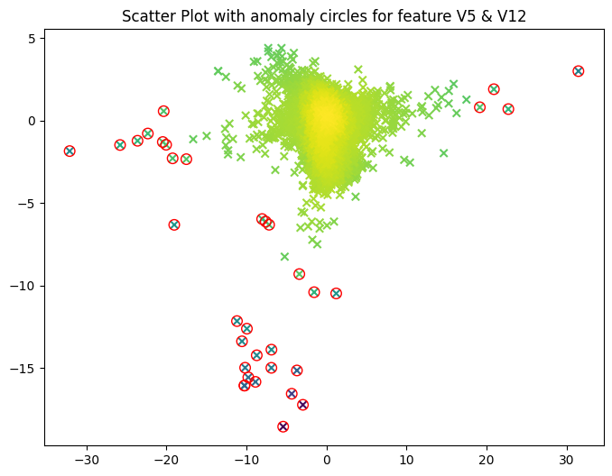

```python
# Create scatter plot to highlight on the scatter plot all points that are below threshold
plt.figure(figsize=(8,6))
plt.scatter(val_v5v12[:,0], val_v5v12[:,1], marker="x", c=score_val_v5v12, cmap='viridis');

# Circling of anomalies
outliers = np.nonzero(score_val_v5v12 < best_threshold_v5v12)[0] # indices for which scores are below the threshold
plt.scatter(val_v5v12[outliers, 0], val_v5v12[outliers, 1], marker="o", facecolor="none", edgecolor="r", s=70)
plt.title('Scatter Plot with anomaly circles for feature V5 & V12')
```

## **Part 4: Single feature model with two Gaussian distributions. [2 Marks]**

Now we will use two different distributions for fraud and not-fraud transactions.

1. Fit a Gaussian distribution ($G_1$) on a feature of **not-fraud transactions** using `sklearn.mixture.GaussianMixture` when `n_components=1`. **[0.25]**
2. Fit another Gaussian distribution ($G_2$) on the same feature but for **fraud transactions** using `sklearn.mixture.GaussianMixture` when `n_components=1`. **[0.25]**
3. Compute the score samples ($S$) for both $G_1$ and $G_2$ on the **validation set** to get $S_1$ and $S_2$, respectively. **[0.25]**
4. Find an optimal $c$ (a real number) that maximizes validation set F1 Score for a model such that if $S_1 < c \times S_2$, the transaction is classified as an anomaly. For example, if $c=1$ we could say that if $S_2$ is greater than $S_1$, ($S_1$<$S_2$) then the transaction is an anomaly (the transaction belongs to the $G_2$ distribution which represents fraud transactions). For start consider $c$ in $[0,10]$ with steps of 0.1, you can change this window in your experiments if needed. **[0.25]**
5. Repeat the steps above for all the features. What is the best F1 Score that you get for training and validation? Which feature and what c? **[1]**

```python
v13_train_nonfraud = X_train['V13'][y_train==0].values.reshape(-1,1)
G1 = GaussianMixture(n_components = 1, covariance_type = 'full', random_state=0, )
G1.fit(v13_train_nonfraud)
S1 = G1.score_samples(X_val['V13'].values.reshape(-1,1))

v13_train_fraud = X_train['V13'][y_train==1].values.reshape(-1,1)
G2 = GaussianMixture(n_components = 1, covariance_type = 'full', random_state=0, )
G2.fit(v13_train_fraud)
S2 = G2.score_samples(X_val['V13'].values.reshape(-1,1))

C = np.arange(0,10.1,0.1)
f1_scores_part4 = []

for c in C:
  f1 = f1_score(y_val, S1 < c*S2)
  f1_scores_part4.append(f1)

best_threshold_part4 = C[np.argmax(f1_scores_part4)]
print(f'Feature V13:\nBest F1 score: {max(f1_scores_part4)} at threshold: {best_threshold_part4}')
```

```
Feature V13:
Best F1 score: 0.005935976256094975 at threshold: 1.1
```

```python
Index = np.arange(28)
C = np.arange(0,10.1,0.1)

for index in Index:
  v_train_nonfraud = X_train.iloc[:,index][y_train==0].values.reshape(-1,1)
  G1 = GaussianMixture(n_components = 1, covariance_type = 'full', random_state=0)
  G1.fit(v_train_nonfraud)
  S1 = G1.score_samples(X_val.iloc[:,index].values.reshape(-1,1))

  v_train_fraud = X_train.iloc[:,index][y_train==1].values.reshape(-1,1)
  G2 = GaussianMixture(n_components = 1, covariance_type = 'full', random_state=0)
  G2.fit(v_train_fraud)
  S2 = G2.score_samples(X_val.iloc[:,index].values.reshape(-1,1))

  f1_scores_current = []
  for c in C:
    f1 = f1_score(y_val, S1 < c*S2)
    f1_scores_current.append(f1)

  best_c_current = C[np.argmax(f1_scores_current)]
  best_f1_current = max(f1_scores_current)

  print(f'Feature V{index+1}:\nBest F1 score: {best_f1_current} at threshold: {best_c_current}\n')
```

```
Feature V1:
Best F1 score: 0.0970873786407767 at threshold: 5.0

Feature V2:
Best F1 score: 0.1111111111111111 at threshold: 3.7

Feature V3:
Best F1 score: 0.2736842105263158 at threshold: 9.9

Feature V4:
Best F1 score: 0.36363636363636365 at threshold: 4.5

Feature V5:
Best F1 score: 0.14606741573033707 at threshold: 5.0

Feature V6:
Best F1 score: 0.10687022900763357 at threshold: 1.9000000000000001

Feature V7:
Best F1 score: 0.20779220779220778 at threshold: 7.800000000000001

Feature V8:
Best F1 score: 0.03870967741935484 at threshold: 4.9

Feature V9:
Best F1 score: 0.3655913978494624 at threshold: 3.3000000000000003

Feature V10:
Best F1 score: 0.34090909090909094 at threshold: 8.6

Feature V11:
Best F1 score: 0.5172413793103449 at threshold: 3.8000000000000003

Feature V12:
Best F1 score: 0.611111111111111 at threshold: 4.800000000000001

Feature V13:
Best F1 score: 0.005935976256094975 at threshold: 1.1

Feature V14:
```

[output cut: 28 more lines]

```

Feature V24:
Best F1 score: 0.005537290188613947 at threshold: 1.7000000000000002

Feature V25:
Best F1 score: 0.017543859649122806 at threshold: 1.7000000000000002

Feature V26:
Best F1 score: 0.003131719173600075 at threshold: 0.0

Feature V27:
Best F1 score: 0.04166666666666667 at threshold: 2.7

Feature V28:
Best F1 score: 0.027465667915106115 at threshold: 1.9000000000000001
```

Best f1 score Feature is: **V17**

It has Best F1 score: **0.6545454545454547** at threshold **C value** is: **7.2**

## **Part 5: Multivariate and Mixture of Gaussians Distribution [4 Marks]**

We now want to build an outlier detection model that performs well in terms of F1 score. To design your model, you can benefit from:

- No restrictions on the number of features - use as few or as many as you want! (multivariate).
- To fit your model, you can take advantage of the Gaussian mixture model, where you can set the number of components [help](https://scikit-learn.org/stable/modules/generated/sklearn.mixture.GaussianMixture.html).
- You can choose to fit your Gaussians on not-fraud transactions or to both classes.

It is up to you how to design your model. Try at least 10 different models and report the AUC for both training and validation sets (if applicable) and the best F1 score for both training and validation sets for each model. What kind of model works better? How many features are best (and which ones)? How many Gaussians? How many components? Summarize your findings with tables or plots. **[4]**

**HINT !**

You might want to try a two-gaussian model, multiple features, a single component for the valid transaction, and multiple components for fraud ones! Why does it make sense to have multiple components for fraud transactions?

**Introduction of self-designed model:** **To find better combinations achieve higher performance, I plan to use model 1 - model 7 using one Gaussian by changing different feture and components to find which features and components are the best using iterations. In moodel 8 - model 10, I plan to use the features and components selected from previous models to build multiple gaussian model to maximize its performance.**

**Model 1: Gaussian model based on one feature v17 on both classes**

```python
from sklearn.mixture import GaussianMixture

# Extract feature v17 from both train and validation set, and fit GMM model
v17_train = X_train['V17'].values.reshape(-1,1)
v17_val = X_val['V17'].values.reshape(-1,1)
gm_v17 = GaussianMixture(n_components = 2, covariance_type = 'full', random_state=0)
gm_v17.fit(v17_train)
score_v17_train = gm_v17.score_samples(v17_train)
score_v17_val = gm_v17.score_samples(v17_val)
auc_train_v17 = roc_auc_score(y_train,-1*score_v17_train)
auc_val_v17 = roc_auc_score(y_val,-1*score_v17_val)

thresholds_v17 = np.linspace(min(score_v17_val), max(score_v17_val), 100) # Generate more threshold value
f1_scores_train_v17 = []
f1_scores_val_v17 = []

# Traverse the thresholds to find the best F1 score for the training set
for threshold in thresholds_v17:
    f1_train = f1_score(y_train, score_v17_train < threshold)
    f1_scores_train_v17.append(f1_train)

# Find the best F1 score and its corresponding threshold for the training set
best_f1_train_v17 = max(f1_scores_train_v17)
best_threshold_train_v17 = thresholds_v17[np.argmax(f1_scores_train_v17)]

# Traverse the thresholds to find the best F1 score for the validation set
for threshold in thresholds_v17:
    f1_val = f1_score(y_val, score_v17_val < threshold)
    f1_scores_val_v17.append(f1_val)

# Find the best F1 score and its corresponding threshold for the validation set
best_f1_val_v17 = max(f1_scores_val_v17)
best_threshold_val_v17 = thresholds_v17[np.argmax(f1_scores_val_v17)]

print(f"For the feature V17:")
print(f"Training AUC: {auc_train_v17}")
print(f"Validation AUC: {auc_val_v17}")
print(f"Best F1 score for training set: {best_f1_train_v17} at threshold: {best_threshold_train_v17}")
print(f"Best F1 score for validation set: {best_f1_val_v17} at threshold: {best_threshold_val_v17}")
```

```
For the feature V17:
Training AUC: 0.9358409520436873
Validation AUC: 0.8841073854248241
Best F1 score for training set: 0.6811145510835912 at threshold: -7.100583377374885
Best F1 score for validation set: 0.6890756302521007 at threshold: -6.8947066089463895
```

From part4, the greatest f1 score occurs at feature v17, so the first model aims to use v17 on n_component = 2 to see its f1 score performance

**Model 2: Gaussian model based on one feature v17 on both classes by traverse different n_component**

```python
component_v17 = np.arange(1, 14)
auc_train_scores = []
auc_val_scores = []
best_f1_train_scores = []
best_f1_val_scores = []

v17_train = X_train['V17'].values.reshape(-1, 1)
v17_val = X_val['V17'].values.reshape(-1, 1)

for comp in component_v17:
    gm_v17 = GaussianMixture(n_components=comp, covariance_type='full', random_state=0)
    gm_v17.fit(v17_train)

    score_v17_train = gm_v17.score_samples(v17_train)
    score_v17_val = gm_v17.score_samples(v17_val)

    auc_train_v17 = roc_auc_score(y_train, -score_v17_train)
    auc_val_v17 = roc_auc_score(y_val, -score_v17_val)

    thresholds = np.linspace(min(score_v17_train), max(score_v17_train), 100)
    f1_scores = [f1_score(y_train, score_v17_train < threshold) for threshold in thresholds]
    best_f1_train = max(f1_scores)

    thresholds = np.linspace(min(score_v17_val), max(score_v17_val), 100)
    f1_scores = [f1_score(y_val, score_v17_val < threshold) for threshold in thresholds]
    best_f1_val = max(f1_scores)

    auc_train_scores.append(auc_train_v17)
    auc_val_scores.append(auc_val_v17)
    best_f1_train_scores.append(best_f1_train)
    best_f1_val_scores.append(best_f1_val)

results = pd.DataFrame({
    'Components': component_v17,
    'AUC_Train': auc_train_scores,
    'AUC_Val': auc_val_scores,
    'Best_F1_Train': best_f1_train_scores,
    'Best_F1_Val': best_f1_val_scores
})

print(results)
```

```
    Components  AUC_Train   AUC_Val  Best_F1_Train  Best_F1_Val
0            1   0.934852  0.881858       0.572944     0.616667
1            2   0.935841  0.884107       0.676783     0.689076
2            3   0.941744  0.896727       0.611024     0.649123
3            4   0.942421  0.895777       0.525114     0.563636
4            5   0.940155  0.892194       0.553377     0.583333
5            6   0.943007  0.894088       0.562569     0.594203
6            7   0.942059  0.895727       0.565702     0.554217
7            8   0.941783  0.887049       0.596244     0.598425
8            9   0.940551  0.898877       0.637838     0.661538
9           10   0.944764  0.894817       0.650259     0.687500
10          11   0.943495  0.895582       0.664697     0.704000
11          12   0.943486  0.895510       0.662808     0.693548
12          13   0.943450  0.895436       0.666667     0.692913
```

As the first model results in a higher f1 score, the second model aims to test feature v17 f1 score performance under different number of gaussian models

```python
print(f'The best f1_score for v17 is: {results["Best_F1_Val"].max()}, at number of mixture components:{results["Best_F1_Val"].argmax()+1}')
```

```
The best f1_score for v17 is: 0.7040000000000001, at number of mixture components:11
```

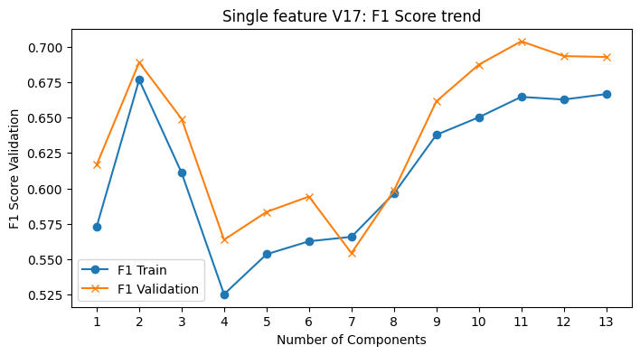

```python
plt.figure(figsize=(8, 4))
plt.plot(results['Components'],results['Best_F1_Train'], marker='o', label='F1 Train')
plt.plot(results['Components'],results['Best_F1_Val'], marker='x', label='F1 Validation')
plt.xlabel('Number of Components')
plt.ylabel('F1 Score Validation')
plt.title('Single feature V17: F1 Score trend')
plt.xticks(results['Components'])
plt.legend()
plt.show()
```

From the traversal of 1 gaussian models to 13 gaussian models to fit v17 feature, the best F1 score for validation set occurs at n_component=11. There is a significant f1_score increase start from n=7, ends at n=11

**Model 3: Gaussian model based full features on both classes**

```python
component_full = np.arange(1, 11)
auc_train_scores = []
auc_val_scores = []
best_f1_train_scores = []
best_f1_val_scores = []

for comp in component_full:
    gm_v17 = GaussianMixture(n_components=comp, covariance_type='full', random_state=0)
    gm_v17.fit(X_train)

    score_full_train = gm_v17.score_samples(X_train)
    score_full_val = gm_v17.score_samples(X_val)

    auc_train_full = roc_auc_score(y_train, -score_full_train)
    auc_val_full = roc_auc_score(y_val, -score_full_val)

    thresholds = np.linspace(min(score_full_train), max(score_full_train), 100)
    f1_scores = [f1_score(y_train, score_full_train < threshold) for threshold in thresholds]
    best_f1_train = max(f1_scores)

    thresholds = np.linspace(min(score_full_val), max(score_full_val), 100)
    f1_scores = [f1_score(y_val, score_full_val < threshold) for threshold in thresholds]
    best_f1_val = max(f1_scores)

    auc_train_scores.append(auc_train_full)
    auc_val_scores.append(auc_val_full)
    best_f1_train_scores.append(best_f1_train)
    best_f1_val_scores.append(best_f1_val)

results = pd.DataFrame({
    'Components': component_full,
    'AUC_Train': auc_train_scores,
    'AUC_Val': auc_val_scores,
    'Best_F1_Train': best_f1_train_scores,
    'Best_F1_Val': best_f1_val_scores
})

print(results)
```

```
   Components  AUC_Train   AUC_Val  Best_F1_Train  Best_F1_Val
0           1   0.953477  0.930669       0.293478     0.258065
1           2   0.931139  0.895806       0.276596     0.252632
2           3   0.931982  0.898034       0.273830     0.250000
3           4   0.930288  0.903056       0.541787     0.461538
4           5   0.937826  0.911515       0.553441     0.450980
5           6   0.933714  0.904209       0.325000     0.338710
6           7   0.933096  0.908813       0.277372     0.280000
7           8   0.927408  0.901689       0.230032     0.237288
8           9   0.923264  0.901442       0.271756     0.250000
9          10   0.927143  0.899793       0.350413     0.362205
```

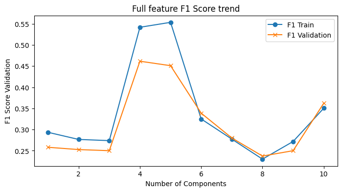

```python
plt.figure(figsize=(8, 4))
plt.plot(results['Components'], results['Best_F1_Train'], marker='o', label='F1 Train')
plt.plot(results['Components'], results['Best_F1_Val'], marker='x', label='F1 Validation')
plt.xlabel('Number of Components')
plt.ylabel('F1 Score Validation')
plt.title('Full feature F1 Score trend')
plt.legend()
plt.show()
```

This model is to contain full features to see the performance of F1 score. As full features contain too many less important and disturbing feature(fraud & non-fraud data stick together), so the highest F1 score is 0.461538 occurs at n_component=4.

**Model 4: Gaussian mixture model based on multiple features V17, V14, V4 for both classes**

```python
from numpy.ma.extras import hstack

component_model4 = np.arange(1,14)
auc_train_scores = []
auc_val_scores = []
best_f1_train_scores = []
best_f1_val_scores = []

v17_train = X_train['V17'].values.reshape(-1, 1)
v14_train = X_train['V14'].values.reshape(-1, 1)
v4_train = X_train['V4'].values.reshape(-1, 1)
v17_val = X_val['V17'].values.reshape(-1, 1)
v14_val = X_val['V14'].values.reshape(-1, 1)
v4_val = X_val['V4'].values.reshape(-1, 1)

v_model4_train = np.hstack((v17_train,v14_train,v4_train))
v_model4_val = np.hstack((v17_val,v14_val,v4_val))

for comp in component_model4:
  gm_model4 = GaussianMixture(n_components = comp, covariance_type = 'full', random_state=0)
  gm_model4.fit(v_model4_train)

  score_model4_train = gm_model4.score_samples(v_model4_train)
  score_model4_val = gm_model4.score_samples(v_model4_val)

  auc_model4_train = roc_auc_score(y_train, -score_model4_train)
  auc_model4_val = roc_auc_score(y_val, -score_model4_val)

  thresholds = np.linspace(min(score_model4_train),max(score_model4_train),100)
  f1_scores = [f1_score(y_train, score_model4_train < threshold) for threshold in thresholds]
  best_f1_train = max(f1_scores)

  thresholds = np.linspace(min(score_model4_val),max(score_model4_val),100)
  f1_scores = [f1_score(y_val, score_model4_val < threshold) for threshold in thresholds]
  best_f1_val = max(f1_scores)

  auc_train_scores.append(auc_model4_train)
  auc_val_scores.append(auc_model4_val)
  best_f1_train_scores.append(best_f1_train)
  best_f1_val_scores.append(best_f1_val)

results = pd.DataFrame({
    'Components': component_model4,
    'AUC_Train': auc_train_scores,
    'AUC_Val': auc_val_scores,
    'Best_F1_Train': best_f1_train_scores,
    'Best_F1_Val': best_f1_val_scores
})

print(results)
```

```
    Components  AUC_Train   AUC_Val  Best_F1_Train  Best_F1_Val
0            1   0.967024  0.945310       0.675362     0.666667
1            2   0.967698  0.945265       0.620419     0.622951
2            3   0.967253  0.945237       0.534954     0.557377
3            4   0.966531  0.941737       0.463636     0.452555
4            5   0.965980  0.940028       0.471139     0.447368
5            6   0.966669  0.939691       0.464615     0.446154
6            7   0.967105  0.942987       0.474097     0.478261
7            8   0.968061  0.940013       0.450420     0.444444
8            9   0.968423  0.937996       0.440252     0.432000
9           10   0.968907  0.936365       0.440129     0.432000
10          11   0.968223  0.936351       0.451827     0.449275
11          12   0.969063  0.937089       0.567391     0.554217
12          13   0.968827  0.937204       0.582796     0.560976
```

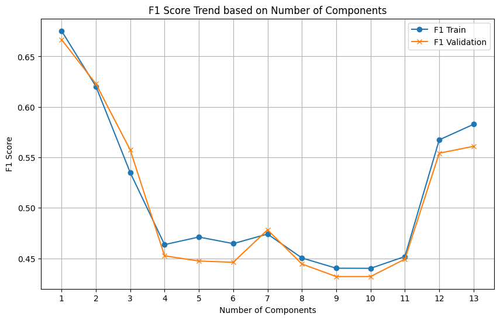

```python
plt.figure(figsize=(10, 6))
plt.plot(results['Components'], results['Best_F1_Train'], marker='o', label='F1 Train')
plt.plot(results['Components'], results['Best_F1_Val'], marker='x', label='F1 Validation')
plt.xlabel('Number of Components')
plt.ylabel('F1 Score')
plt.title('F1 Score Trend based on Number of Components')
plt.legend()
plt.grid(True)
plt.xticks(results['Components'])
plt.show()
```

We can see at n=1, the multiple gaussian model based on feature v17, v14, v4 has the highest f1 score which is 0.667

**Model 5: Gaussian model based on feature v17,14,v4 for non-fraud class**

```python
component_model5 = np.arange(1,14)
auc_train_scores = []
auc_val_scores = []
best_f1_train_scores = []
best_f1_val_scores = []

v17_train_nf = X_train['V17'][y_train==0].values.reshape(-1, 1)
v14_train_nf = X_train['V14'][y_train==0].values.reshape(-1, 1)
v4_train_nf = X_train['V4'][y_train==0].values.reshape(-1, 1)
v_model5_nf = np.hstack((v17_train_nf,v14_train_nf,v4_train_nf))

v17_train = X_train['V17'].values.reshape(-1, 1)
v14_train = X_train['V14'].values.reshape(-1, 1)
v4_train = X_train['V4'].values.reshape(-1, 1)
v17_val = X_val['V17'].values.reshape(-1, 1)
v14_val = X_val['V14'].values.reshape(-1, 1)
v4_val = X_val['V4'].values.reshape(-1, 1)

v_model5_train = np.hstack((v17_train,v14_train,v4_train))
v_model5_val = np.hstack((v17_val,v14_val,v4_val))

for comp in component_model5:
  gm_model5 = GaussianMixture(n_components = comp, covariance_type = 'full', random_state=0)
  gm_model5.fit(v_model5_nf)

  score_model5_train = gm_model5.score_samples(v_model5_train)
  score_model5_val = gm_model5.score_samples(v_model5_val)

  auc_model5_train = roc_auc_score(y_train, -score_model5_train)
  auc_model5_val = roc_auc_score(y_val, -score_model5_val)

  thresholds = np.linspace(min(score_model5_train),max(score_model5_train),100)
  f1_scores = [f1_score(y_train, score_model5_train < threshold) for threshold in thresholds]
  best_f1_train = max(f1_scores)

  thresholds = np.linspace(min(score_model5_val),max(score_model5_val),100)
  f1_scores = [f1_score(y_val, score_model5_val < threshold) for threshold in thresholds]
  best_f1_val = max(f1_scores)

  auc_train_scores.append(auc_model5_train)
  auc_val_scores.append(auc_model5_val)
  best_f1_train_scores.append(best_f1_train)
  best_f1_val_scores.append(best_f1_val)

results = pd.DataFrame({
    'Components': component_model5,
    'AUC_Train': auc_train_scores,
    'AUC_Val': auc_val_scores,
    'Best_F1_Train': best_f1_train_scores,
    'Best_F1_Val': best_f1_val_scores
})

print(results)
```

```
    Components  AUC_Train   AUC_Val  Best_F1_Train  Best_F1_Val
0            1   0.966064  0.943144       0.699849     0.697674
1            2   0.968574  0.945125       0.703956     0.699187
2            3   0.968078  0.942833       0.681097     0.676692
3            4   0.968722  0.940996       0.736842     0.666667
4            5   0.968261  0.943867       0.650847     0.643478
5            6   0.967923  0.941575       0.736994     0.666667
6            7   0.969696  0.941421       0.716547     0.640625
7            8   0.969684  0.938660       0.731572     0.672414
8            9   0.970124  0.937217       0.710335     0.640000
9           10   0.968847  0.936665       0.645862     0.622951
10          11   0.968748  0.936796       0.620408     0.611570
11          12   0.968932  0.936849       0.609626     0.612903
12          13   0.969066  0.937566       0.624495     0.601626
```

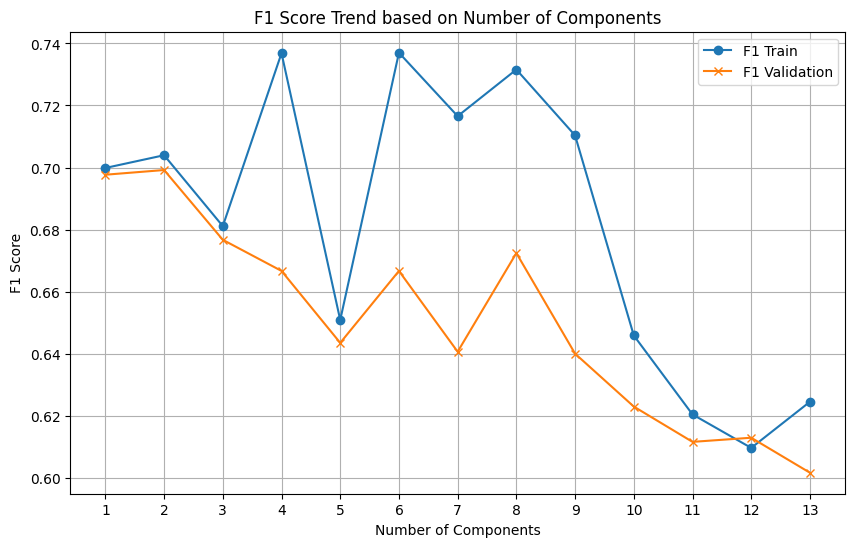

```python
plt.figure(figsize=(10, 6))
plt.plot(results['Components'], results['Best_F1_Train'], marker='o', label='F1 Train')
plt.plot(results['Components'], results['Best_F1_Val'], marker='x', label='F1 Validation')
plt.xlabel('Number of Components')
plt.ylabel('F1 Score')
plt.title('F1 Score Trend based on Number of Components')
plt.legend()
plt.grid(True)
plt.xticks(results['Components'])
plt.show()
```

The purpose of model 5 is to train the multiple gaussian model using feature v17,v14,v4 based on non-fraud class to see whether the performance changes.

Through the table and plot above, both f1 score training and f1 score validation increase a lot compared to model 4. The best F1 score validation occurs at n_component=2, which is 0.699187. This phenomenon shows that discard fraud dataset will improve the model performance.

**Model 6: Gaussian model based on feature v17,14,v10 for non-fraud class**

```python
component_model6 = np.arange(1,14)
auc_train_scores_m6 = []
auc_val_scores_m6 = []
best_f1_train_scores_m6 = []
best_f1_val_scores_m6 = []

v17_train_nf = X_train['V17'][y_train==0].values.reshape(-1, 1)
v14_train_nf = X_train['V14'][y_train==0].values.reshape(-1, 1)
v10_train_nf = X_train['V10'][y_train==0].values.reshape(-1, 1)
v_model6_nf = np.hstack((v17_train_nf,v14_train_nf,v10_train_nf))

v17_train = X_train['V17'].values.reshape(-1, 1)
v14_train = X_train['V14'].values.reshape(-1, 1)
v10_train = X_train['V10'].values.reshape(-1, 1)
v17_val = X_val['V17'].values.reshape(-1, 1)
v14_val = X_val['V14'].values.reshape(-1, 1)
v10_val = X_val['V10'].values.reshape(-1, 1)

v_model6_train = np.hstack((v17_train,v14_train,v10_train))
v_model6_val = np.hstack((v17_val,v14_val,v10_val))

for comp in component_model6:
  gm_model6 = GaussianMixture(n_components = comp, covariance_type = 'full', random_state=0)
  gm_model6.fit(v_model6_nf)

  score_model6_train = gm_model6.score_samples(v_model6_train)
  score_model6_val = gm_model6.score_samples(v_model6_val)

  auc_model6_train = roc_auc_score(y_train, -score_model6_train)
  auc_model6_val = roc_auc_score(y_val, -score_model6_val)

  thresholds = np.linspace(min(score_model6_train),max(score_model6_train),100)
  f1_scores = [f1_score(y_train, score_model6_train < threshold) for threshold in thresholds]
  best_f1_train = max(f1_scores)

  thresholds = np.linspace(min(score_model6_val),max(score_model6_val),100)
  f1_scores = [f1_score(y_val, score_model6_val < threshold) for threshold in thresholds]
  best_f1_val = max(f1_scores)

  auc_train_scores_m6.append(auc_model6_train)
  auc_val_scores_m6.append(auc_model6_val)
  best_f1_train_scores_m6.append(best_f1_train)
  best_f1_val_scores_m6.append(best_f1_val)

table_model6 = pd.DataFrame({
    'Components': component_model6,
    'AUC_Train': auc_train_scores_m6,
    'AUC_Val': auc_val_scores_m6,
    'Best_F1_Train': best_f1_train_scores_m6,
    'Best_F1_Val': best_f1_val_scores_m6
})

print(table_model6)
```

```
    Components  AUC_Train   AUC_Val  Best_F1_Train  Best_F1_Val
0            1   0.960563  0.950209       0.640502     0.571429
1            2   0.962150  0.953094       0.731481     0.678261
2            3   0.960883  0.955512       0.705219     0.724409
3            4   0.960179  0.950888       0.645570     0.638655
4            5   0.962686  0.952560       0.729614     0.708661
5            6   0.963635  0.950861       0.692737     0.707692
6            7   0.963228  0.949784       0.685246     0.696970
7            8   0.963477  0.950318       0.681818     0.691729
8            9   0.963355  0.950245       0.622771     0.632353
9           10   0.964501  0.948012       0.625899     0.616541
10          11   0.964688  0.947155       0.602673     0.596491
11          12   0.964517  0.948214       0.607903     0.601770
12          13   0.964970  0.947010       0.697422     0.661765
```

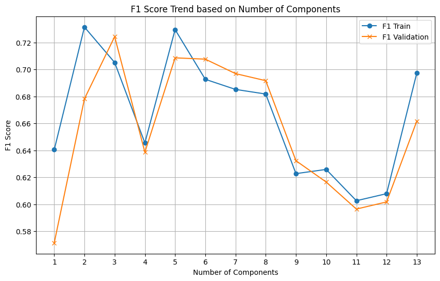

```python
plt.figure(figsize=(10, 6))
plt.plot(table_model6['Components'], table_model6['Best_F1_Train'], marker='o', label='F1 Train')
plt.plot(table_model6['Components'], table_model6['Best_F1_Val'], marker='x', label='F1 Validation')
plt.xlabel('Number of Components')
plt.ylabel('F1 Score')
plt.title('F1 Score Trend based on Number of Components')
plt.legend()
plt.grid(True)
plt.xticks(table_model6['Components'])
plt.show()
```

As model 5 has significant increment in f1 score by using non-fraud class to fit the model, the goal of model 6 is to test the performance if we switch another feature into the model. In part 1a, feature v10 is one of the greatest f1 score. So we replace v4 by v10.

**Model 7: Gaussian model based on full feature for fraud class**

```python
component_model7 = np.arange(1, 14)
auc_train_scores_model7 = []
auc_val_scores_model7 = []
best_f1_train_scores_model7 = []
best_f1_val_scores_model7 = []

X_train_fraud = X_train[y_train == 1]

for comp in component_model7:
    gm_model7 = GaussianMixture(n_components=comp, covariance_type='full', random_state=0)
    gm_model7.fit(X_train_fraud)

    score_full_train = gm_model7.score_samples(X_train)
    score_full_val = gm_model7.score_samples(X_val)

    auc_train_full = roc_auc_score(y_train, -score_full_train)
    auc_val_full = roc_auc_score(y_val, -score_full_val)

    thresholds = np.linspace(min(score_full_train), max(score_full_train), 100)
    f1_scores = [f1_score(y_train, score_full_train < threshold) for threshold in thresholds]
    best_f1_train = max(f1_scores)

    thresholds = np.linspace(min(score_full_val), max(score_full_val), 100)
    f1_scores = [f1_score(y_val, score_full_val < threshold) for threshold in thresholds]
    best_f1_val = max(f1_scores)

    auc_train_scores_model7.append(auc_train_full)
    auc_val_scores_model7.append(auc_val_full)
    best_f1_train_scores_model7.append(best_f1_train)
    best_f1_val_scores_model7.append(best_f1_val)

results_model7 = pd.DataFrame({
    'Components': component_model7,
    'AUC_Train': auc_train_scores_model7,
    'AUC_Val': auc_val_scores_model7,
    'Best_F1_Train': best_f1_train_scores_model7,
    'Best_F1_Val': best_f1_val_scores_model7
})

print(results_model7)
```

```
    Components  AUC_Train   AUC_Val  Best_F1_Train  Best_F1_Val
0            1   0.295603  0.354361       0.003445     0.003132
1            2   0.228278  0.335557       0.003445     0.007353
2            3   0.233042  0.324469       0.003415     0.006920
3            4   0.205584  0.343775       0.003415     0.004751
4            5   0.315838  0.407153       0.003445     0.003085
5            6   0.282700  0.382847       0.003395     0.003210
6            7   0.201941  0.339542       0.003395     0.005540
7            8   0.203500  0.459083       0.003395     0.006380
8            9   0.156040  0.415909       0.003395     0.006098
9           10   0.156036  0.431341       0.003395     0.006094
10          11   0.132566  0.432119       0.003395     0.004024
11          12   0.132570  0.421795       0.003395     0.003929
12          13   0.132563  0.436218       0.003395     0.009804
```

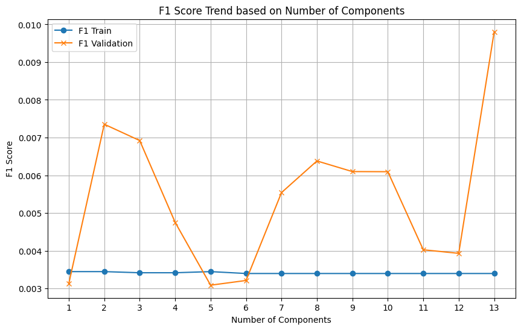

```python
plt.figure(figsize=(10, 6))
plt.plot(results_model7['Components'], results_model7['Best_F1_Train'], marker='o', label='F1 Train')
plt.plot(results_model7['Components'], results_model7['Best_F1_Val'], marker='x', label='F1 Validation')
plt.xlabel('Number of Components')
plt.ylabel('F1 Score')
plt.title('F1 Score Trend based on Number of Components')
plt.legend()
plt.grid(True)
plt.xticks(results_model7['Components'])
plt.show()
```

The orignial purpose for model 7 is to adjust the class to fraud transactions because we haven't try to fit fraud data into model yet.

However, as the fraud transaction set is extremely dispersed and not enough, the f1 score for training and validation are extremely low. Next is to try the combination of fraud and non-fraud transactions to fit two gaussian models.

**Model 8: Two gaussian models based on multiple features v17,v14,v10 by default n_component setting**

```python
# Using non-fraud data
v17_train_nf = X_train['V17'][y_train==0].values.reshape(-1, 1)
v14_train_nf = X_train['V14'][y_train==0].values.reshape(-1, 1)
v10_train_nf = X_train['V10'][y_train==0].values.reshape(-1, 1)
v_model8_nf_train = np.hstack((v17_train_nf,v14_train_nf,v10_train_nf))

gm8_nf = GaussianMixture(n_components = 3, covariance_type = 'full', random_state=0)
gm8_nf.fit(v_model8_nf_train)

v17_val = X_val['V17'].values.reshape(-1, 1)
v14_val = X_val['V14'].values.reshape(-1, 1)
v10_val = X_val['V10'].values.reshape(-1, 1)
v_model8_val = np.hstack((v17_val, v14_val, v10_val))

score_model8_nf_val = gm8_nf.score_samples(v_model8_val)

# Using fraud data
v17_train_f = X_train['V17'][y_train==1].values.reshape(-1, 1)
v14_train_f = X_train['V14'][y_train==1].values.reshape(-1, 1)
v10_train_f = X_train['V10'][y_train==1].values.reshape(-1, 1)
v_model8_f_train = np.hstack((v17_train_f,v14_train_f,v10_train_f))

gm8_f = GaussianMixture(n_components = 6, covariance_type = 'full', random_state=0)
gm8_f.fit(v_model8_f_train)

score_model8_f_val = gm8_f.score_samples(v_model8_val)


C = np.arange(0, 10.1, 0.1)
f1_scores_model8 = []

for c in C:
    predictions = score_model8_nf_val < c * score_model8_f_val
    f1 = f1_score(y_val, predictions)
    f1_scores_model8.append(f1)

print(f'Combined Model using V17, V14, V10:\nBest F1 score: {max(f1_scores_model8)}')
```

```
Combined Model using V17, V14, V10:
Best F1 score: 0.7812500000000001
```

Use v17,v14,v10 non-fraud to fit the first gaussian model, and fraud transaction to fit the second model. Apply the method used in part 4 to use two gaussian model scores and constant C to get predictions and return best F1 score.

For non-fraud gaussian n_component choose 3 is because in model 3 the highest F1 score occurs at n_component=3. For fraud gaussian component choose 6 is because the fraud data is more complex and dispersed, so we pick a value larger than 3 to fit the model.

The Best F1 score validation is **0.7812** in this iteration, which is better than all models before.

**Model 9: Two gaussian models based on multiple features v17,v14,v10 for both classes with different n_component**

```python
nf_comp_model9 = np.arange(2,10)
f_comp_model9 = np.arange(4,10)

# Using non-fraud data
v17_train_nf = X_train['V17'][y_train==0].values.reshape(-1, 1)
v14_train_nf = X_train['V14'][y_train==0].values.reshape(-1, 1)
v10_train_nf = X_train['V10'][y_train==0].values.reshape(-1, 1)
v_model9_nf_train = np.hstack((v17_train_nf,v14_train_nf,v10_train_nf))

v17_val = X_val['V17'].values.reshape(-1, 1)
v14_val = X_val['V14'].values.reshape(-1, 1)
v10_val = X_val['V10'].values.reshape(-1, 1)
v_model9_val = np.hstack((v17_val, v14_val, v10_val))

# Using fraud data
v17_train_f = X_train['V17'][y_train==1].values.reshape(-1, 1)
v14_train_f = X_train['V14'][y_train==1].values.reshape(-1, 1)
v10_train_f = X_train['V10'][y_train==1].values.reshape(-1, 1)
v_model9_f_train = np.hstack((v17_train_f,v14_train_f,v10_train_f))

results = []

for nf in nf_comp_model9:
    gm9_nf = GaussianMixture(n_components=nf, covariance_type='full', random_state=0)
    gm9_nf.fit(v_model9_nf_train)
    score_model9_nf_val = gm9_nf.score_samples(v_model9_val)

    for f in f_comp_model9:
        gm9_f = GaussianMixture(n_components=f, covariance_type='full', random_state=0)
        gm9_f.fit(v_model9_f_train)
        score_model9_f_val = gm9_f.score_samples(v_model9_val)

        # Compute for F1 score using c value range 0 - 10
        C = np.arange(0, 10.1, 0.1)
        f1_scores_model9 = []

        for c in C:
            predictions = score_model9_nf_val < c * score_model9_f_val
            f1 = f1_score(y_val, predictions)
            f1_scores_model9.append(f1)

        max_f1 = max(f1_scores_model9)
        best_c_current = C[np.argmax(f1_scores_model9)]
        results.append((nf, f, best_c_current, max_f1))
        print(f'NF Components: {nf}, F Components: {f} - Threshold: {best_c_current} Best F1 score: {max_f1}')

# Convert results to DataFrame for better readability
results_model9 = pd.DataFrame(results, columns=['NF_Components', 'F_Components', 'Threshold', 'Best_F1'])
print(results_model9)
```

```
NF Components: 2, F Components: 4 - Threshold: 2.1 Best F1 score: 0.7874015748031497
NF Components: 2, F Components: 5 - Threshold: 2.1 Best F1 score: 0.7874015748031497
NF Components: 2, F Components: 6 - Threshold: 2.3000000000000003 Best F1 score: 0.7868852459016392
NF Components: 2, F Components: 7 - Threshold: 2.3000000000000003 Best F1 score: 0.7868852459016392
NF Components: 2, F Components: 8 - Threshold: 1.9000000000000001 Best F1 score: 0.784
NF Components: 2, F Components: 9 - Threshold: 1.8 Best F1 score: 0.7812500000000001
NF Components: 3, F Components: 4 - Threshold: 2.6 Best F1 score: 0.7563025210084034
NF Components: 3, F Components: 5 - Threshold: 2.4000000000000004 Best F1 score: 0.7479674796747967
NF Components: 3, F Components: 6 - Threshold: 1.9000000000000001 Best F1 score: 0.7812500000000001
NF Components: 3, F Components: 7 - Threshold: 1.9000000000000001 Best F1 score: 0.7812500000000001
NF Components: 3, F Components: 8 - Threshold: 2.0 Best F1 score: 0.768
NF Components: 3, F Components: 9 - Threshold: 2.0 Best F1 score: 0.768
NF Components: 4, F Components: 4 - Threshold: 2.3000000000000003 Best F1 score: 0.8062015503875968
NF Components: 4, F Components: 5 - Threshold: 2.3000000000000003 Best F1 score: 0.8062015503875968
NF Components: 4, F Components: 6 - Threshold: 1.8 Best F1 score: 0.8
NF Components: 4, F Components: 7 - Threshold: 1.8 Best F1 score: 0.8
NF Components: 4, F Components: 8 - Threshold: 2.7 Best F1 score: 0.7967479674796748
NF Components: 4, F Components: 9 - Threshold: 2.1 Best F1 score: 0.796875
NF Components: 5, F Components: 4 - Threshold: 2.0 Best F1 score: 0.7500000000000001
NF Components: 5, F Components: 5 - Threshold: 2.1 Best F1 score: 0.746031746031746
NF Components: 5, F Components: 6 - Threshold: 2.2 Best F1 score: 0.7627118644067797
NF Components: 5, F Components: 7 - Threshold: 2.2 Best F1 score: 0.7627118644067797
NF Components: 5, F Components: 8 - Threshold: 2.2 Best F1 score: 0.7666666666666666
NF Components: 5, F Components: 9 - Threshold: 2.2 Best F1 score: 0.7666666666666666
NF Components: 6, F Components: 4 - Threshold: 1.7000000000000002 Best F1 score: 0.7936507936507936
NF Components: 6, F Components: 5 - Threshold: 1.7000000000000002 Best F1 score: 0.796875
NF Components: 6, F Components: 6 - Threshold: 1.8 Best F1 score: 0.784
NF Components: 6, F Components: 7 - Threshold: 1.8 Best F1 score: 0.784
NF Components: 6, F Components: 8 - Threshold: 2.2 Best F1 score: 0.7833333333333334
NF Components: 6, F Components: 9 - Threshold: 2.1 Best F1 score: 0.7768595041322315
NF Components: 7, F Components: 4 - Threshold: 1.7000000000000002 Best F1 score: 0.7936507936507936
NF Components: 7, F Components: 5 - Threshold: 1.7000000000000002 Best F1 score: 0.796875
NF Components: 7, F Components: 6 - Threshold: 1.8 Best F1 score: 0.784
NF Components: 7, F Components: 7 - Threshold: 1.8 Best F1 score: 0.784
NF Components: 7, F Components: 8 - Threshold: 2.2 Best F1 score: 0.7833333333333334
NF Components: 7, F Components: 9 - Threshold: 1.9000000000000001 Best F1 score: 0.7804878048780487
NF Components: 8, F Components: 4 - Threshold: 1.7000000000000002 Best F1 score: 0.7936507936507936
NF Components: 8, F Components: 5 - Threshold: 1.7000000000000002 Best F1 score: 0.796875
NF Components: 8, F Components: 6 - Threshold: 1.8 Best F1 score: 0.784
NF Components: 8, F Components: 7 - Threshold: 1.8 Best F1 score: 0.784
```

[output cut: 42 more lines]

```
33              7             7        1.8  0.784000
34              7             8        2.2  0.783333
35              7             9        1.9  0.780488
36              8             4        1.7  0.793651
37              8             5        1.7  0.796875
38              8             6        1.8  0.784000
39              8             7        1.8  0.784000
40              8             8        2.2  0.783333
41              8             9        1.9  0.780488
42              9             4        1.7  0.775194
43              9             5        1.6  0.757576
44              9             6        1.6  0.774194
45              9             7        1.6  0.774194
46              9             8        1.7  0.776860
47              9             9        1.7  0.776860
```

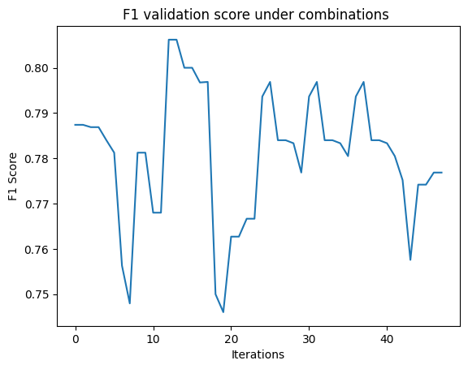

```python
plt.plot(results_model9['Best_F1'],label='Best F1 score')
plt.xlabel('Iterations')
plt.ylabel('F1 Score')
plt.title('F1 validation score under combinations ')
plt.show()
```

In model 8, we only try one combination of number of mixture component n, the purpose of model 9 is to traverse more possible combinations to find if there is better combination exists.

**The best combination in model 9 occurs at:**

Non-fraud Components: 4, Fraud Components: 4 - Threshold: 2.3 Best F1 score: 0.8062015503875968

Non_fraud Components: 4, Fraud Components: 5 - Threshold: 2.3 Best F1 score: 0.8062015503875968

**Model 10: Two gaussian models based on multiple features v17,v14,v12 for both classes with different n_component**

```python
nf_comp_model10 = np.arange(2,10)
f_comp_model10 = np.arange(4,10)

# Using non-fraud data
v17_train_nf = X_train['V17'][y_train==0].values.reshape(-1, 1)
v14_train_nf = X_train['V14'][y_train==0].values.reshape(-1, 1)
v12_train_nf = X_train['V12'][y_train==0].values.reshape(-1, 1)
v_model10_nf_train = np.hstack((v17_train_nf,v14_train_nf,v12_train_nf))

v17_val = X_val['V17'].values.reshape(-1, 1)
v14_val = X_val['V14'].values.reshape(-1, 1)
v12_val = X_val['V12'].values.reshape(-1, 1)
v_model10_val = np.hstack((v17_val, v14_val, v12_val))

# Using fraud data
v17_train_f = X_train['V17'][y_train==1].values.reshape(-1, 1)
v14_train_f = X_train['V14'][y_train==1].values.reshape(-1, 1)
v12_train_f = X_train['V12'][y_train==1].values.reshape(-1, 1)
v_model10_f_train = np.hstack((v17_train_f,v14_train_f,v12_train_f))

results = []

for nf in nf_comp_model10:
    gm10_nf = GaussianMixture(n_components=nf, covariance_type='full', random_state=0)
    gm10_nf.fit(v_model10_nf_train)
    score_model10_nf_val = gm10_nf.score_samples(v_model10_val)

    for f in f_comp_model10:
        gm10_f = GaussianMixture(n_components=f, covariance_type='full', random_state=0)
        gm10_f.fit(v_model10_f_train)
        score_model10_f_val = gm10_f.score_samples(v_model10_val)

        # Compute for F1 score using c value range 0 - 10
        C = np.arange(0, 10.1, 0.1)
        f1_scores_model10 = []

        for c in C:
            predictions = score_model10_nf_val < c * score_model10_f_val
            f1 = f1_score(y_val, predictions)
            f1_scores_model10.append(f1)

        max_f1 = max(f1_scores_model10)
        best_c_current = C[np.argmax(f1_scores_model10)]
        results.append((nf, f, max_f1, best_c_current))
        print(f'NF Components: {nf}, F Components: {f} - Best threshold: {best_c_current} Best F1 score: {max_f1}')

# Convert results to DataFrame for better readability
results_model10 = pd.DataFrame(results, columns=['NF_Components', 'F_Components', 'best_c_current', 'Best_F1'])
print(results_model10)
```

```
NF Components: 2, F Components: 4 - Best threshold: 2.4000000000000004 Best F1 score: 0.7777777777777778
NF Components: 2, F Components: 5 - Best threshold: 2.4000000000000004 Best F1 score: 0.7777777777777778
NF Components: 2, F Components: 6 - Best threshold: 2.6 Best F1 score: 0.7716535433070867
NF Components: 2, F Components: 7 - Best threshold: 2.3000000000000003 Best F1 score: 0.7786259541984732
NF Components: 2, F Components: 8 - Best threshold: 2.6 Best F1 score: 0.7741935483870968
NF Components: 2, F Components: 9 - Best threshold: 2.5 Best F1 score: 0.7874015748031497
NF Components: 3, F Components: 4 - Best threshold: 2.7 Best F1 score: 0.7642276422764228
NF Components: 3, F Components: 5 - Best threshold: 2.9000000000000004 Best F1 score: 0.7642276422764228
NF Components: 3, F Components: 6 - Best threshold: 2.4000000000000004 Best F1 score: 0.7761194029850746
NF Components: 3, F Components: 7 - Best threshold: 2.4000000000000004 Best F1 score: 0.7938931297709924
NF Components: 3, F Components: 8 - Best threshold: 2.4000000000000004 Best F1 score: 0.7938931297709924
NF Components: 3, F Components: 9 - Best threshold: 2.3000000000000003 Best F1 score: 0.7846153846153846
NF Components: 4, F Components: 4 - Best threshold: 1.8 Best F1 score: 0.765625
NF Components: 4, F Components: 5 - Best threshold: 1.8 Best F1 score: 0.765625
NF Components: 4, F Components: 6 - Best threshold: 1.9000000000000001 Best F1 score: 0.768
NF Components: 4, F Components: 7 - Best threshold: 1.9000000000000001 Best F1 score: 0.7741935483870968
NF Components: 4, F Components: 8 - Best threshold: 1.9000000000000001 Best F1 score: 0.7741935483870968
NF Components: 4, F Components: 9 - Best threshold: 1.8 Best F1 score: 0.7777777777777778
NF Components: 5, F Components: 4 - Best threshold: 1.9000000000000001 Best F1 score: 0.7394957983193277
NF Components: 5, F Components: 5 - Best threshold: 1.7000000000000002 Best F1 score: 0.7441860465116278
NF Components: 5, F Components: 6 - Best threshold: 1.8 Best F1 score: 0.7804878048780487
NF Components: 5, F Components: 7 - Best threshold: 1.9000000000000001 Best F1 score: 0.7563025210084034
NF Components: 5, F Components: 8 - Best threshold: 1.8 Best F1 score: 0.7642276422764228
NF Components: 5, F Components: 9 - Best threshold: 1.7000000000000002 Best F1 score: 0.7777777777777778
NF Components: 6, F Components: 4 - Best threshold: 1.7000000000000002 Best F1 score: 0.7401574803149608
NF Components: 6, F Components: 5 - Best threshold: 1.7000000000000002 Best F1 score: 0.7401574803149608
NF Components: 6, F Components: 6 - Best threshold: 1.8 Best F1 score: 0.7603305785123967
NF Components: 6, F Components: 7 - Best threshold: 1.8 Best F1 score: 0.7131782945736433
NF Components: 6, F Components: 8 - Best threshold: 1.8 Best F1 score: 0.7317073170731707
NF Components: 6, F Components: 9 - Best threshold: 1.7000000000000002 Best F1 score: 0.7741935483870968
NF Components: 7, F Components: 4 - Best threshold: 1.8 Best F1 score: 0.7457627118644067
NF Components: 7, F Components: 5 - Best threshold: 1.8 Best F1 score: 0.7457627118644067
NF Components: 7, F Components: 6 - Best threshold: 1.9000000000000001 Best F1 score: 0.7692307692307693
NF Components: 7, F Components: 7 - Best threshold: 1.9000000000000001 Best F1 score: 0.7288135593220338
NF Components: 7, F Components: 8 - Best threshold: 1.9000000000000001 Best F1 score: 0.7368421052631579
NF Components: 7, F Components: 9 - Best threshold: 1.8 Best F1 score: 0.7768595041322315
NF Components: 8, F Components: 4 - Best threshold: 1.8 Best F1 score: 0.7394957983193277
NF Components: 8, F Components: 5 - Best threshold: 1.8 Best F1 score: 0.7394957983193277
NF Components: 8, F Components: 6 - Best threshold: 1.8 Best F1 score: 0.7540983606557378
NF Components: 8, F Components: 7 - Best threshold: 1.9000000000000001 Best F1 score: 0.7118644067796609
```

[output cut: 42 more lines]

```
33              7             7        0.728814      1.9
34              7             8        0.736842      1.9
35              7             9        0.776860      1.8
36              8             4        0.739496      1.8
37              8             5        0.739496      1.8
38              8             6        0.754098      1.8
39              8             7        0.711864      1.9
40              8             8        0.724138      1.9
41              8             9        0.784000      1.7
42              9             4        0.723077      1.7
43              9             5        0.723077      1.7
44              9             6        0.697674      1.7
45              9             7        0.747967      1.7
46              9             8        0.754098      1.7
47              9             9        0.747967      1.7
```

[figure not shown]

```python
plt.plot(results_model10['Best_F1'],label='Best F1 score')
plt.xlabel('Iterations')
plt.ylabel('F1 Score')
plt.title('F1 validation score under combinations ')
plt.show()
```

The best combination occurs at:

NF Components: 3, F Components: 7 - Best F1 score: 0.7938931297709924

# **Summary:**

The best F1 score occurs at model 9: Two gaussian models based on features v17,v14,v10 for both classes with:

**Non-fraud Components: 4, Fraud Components: 4 - Threshold: 2.3 Best F1 score: 0.8062015503875968**

**Non_fraud Components: 4, Fraud Components: 5 - Threshold: 2.3 Best F1 score: 0.8062015503875968**

These two combinations of component both gives the same highest F1 score for validation set. We will use this model for evaluation in test set.

## **Part 6: Evaluating performance on test set: [1 Mark]**

**Which model worked better?** Pick your best model among all models and apply it to your test set. Report the F1 Score, Precision and Recall on the test set. **[1]**

```python
# Pick the model 9: with two gaussian models for feature v17,v14,v10 for both classes

# Evaluating formance on Non-fraud Components: 4, Fraud Components: 4

from sklearn.metrics import precision_score
from sklearn.metrics import recall_score

gm9_nf = GaussianMixture(n_components=4, covariance_type='full', random_state=0)
gm9_nf.fit(v_model9_nf_train)
gm9_f = GaussianMixture(n_components=4, covariance_type='full', random_state=0)
gm9_f.fit(v_model9_f_train)

# Setup for the test set
v17_test = X_test['V17'].values.reshape(-1, 1)
v14_test = X_test['V14'].values.reshape(-1, 1)
v10_test = X_test['V10'].values.reshape(-1, 1)
v_model9_test = np.hstack((v17_test, v14_test, v10_test))

# Use gaussian models from model 9, score samples based on corresponding test data
score_model9_nf_test = gm9_nf.score_samples(v_model9_test)
score_model9_f_test = gm9_f.score_samples(v_model9_test)

# Find the best threshold c on the test set
C = np.arange(0, 10.1, 0.1)
best_f1 = 0
best_c = 0

for c in C:
    predictions_test = score_model9_nf_test < c * score_model9_f_test
    f1 = f1_score(y_test, predictions_test)
    if f1 > best_f1:
        best_f1 = f1
        best_c = c

# Use the best threshold from the test set to get precision and recall score
predictions_test = score_model9_nf_test < best_c * score_model9_f_test
precision = precision_score(y_test, predictions_test)
recall = recall_score(y_test, predictions_test)

print('Evaluating formance on Model 9 - Non-fraud Components: 4, Fraud Components: 4')
print()
print(f"Best Threshold on Test Set: {best_c}")
print(f"F1 Score on Test Set: {best_f1}")
print(f"Precision on Test Set: {precision}")
print(f"Recall on Test Set: {recall}")
```

```
Evaluating formance on Model 9 - Non-fraud Components: 4, Fraud Components: 4

Best Threshold on Test Set: 2.6
F1 Score on Test Set: 0.8125
Precision on Test Set: 0.8125
Recall on Test Set: 0.8125
```

```python
 # Pick the model 9: with two gaussian models for feature v17,v14,v10 for both classes

# Evaluating formance on Non-fraud Components: 4, Fraud Components: 5
gm9_nf = GaussianMixture(n_components=4, covariance_type='full', random_state=0)
gm9_nf.fit(v_model9_nf_train)
gm9_f = GaussianMixture(n_components=5, covariance_type='full', random_state=0)
gm9_f.fit(v_model9_f_train)

# Setup for the test set
v17_test = X_test['V17'].values.reshape(-1, 1)
v14_test = X_test['V14'].values.reshape(-1, 1)
v10_test = X_test['V10'].values.reshape(-1, 1)
v_model9_test = np.hstack((v17_test, v14_test, v10_test))

# Use gaussian models from model 9, score samples based on corresponding test data
score_model9_nf_test = gm9_nf.score_samples(v_model9_test)
score_model9_f_test = gm9_f.score_samples(v_model9_test)

# Find the best threshold c on the test set
C = np.arange(0, 10.1, 0.1)
best_f1 = 0
best_c = 0

for c in C:
    predictions_test = score_model9_nf_test < c * score_model9_f_test
    f1 = f1_score(y_test, predictions_test)
    if f1 > best_f1:
        best_f1 = f1
        best_c = c

# Use the best threshold from the test set to get precision and recall score
predictions_test = score_model9_nf_test < best_c * score_model9_f_test
precision = precision_score(y_test, predictions_test)
recall = recall_score(y_test, predictions_test)

print('Evaluating formance on Model 9 - Non-fraud Components: 4, Fraud Components: 5')
print()
print(f"Best Threshold on Test Set: {best_c}")
print(f"F1 Score on Test Set: {best_f1}")
print(f"Precision on Test Set: {precision}")
print(f"Recall on Test Set: {recall}")
```

```
Evaluating formance on Model 9 - Non-fraud Components: 4, Fraud Components: 5

Best Threshold on Test Set: 2.5
F1 Score on Test Set: 0.8000000000000002
Precision on Test Set: 0.8
Recall on Test Set: 0.8
```

Evaluating formance on Model 9 - Non-fraud Components: 4, Fraud Components: 4 results in a test F1 score 0.8125

Evaluating formance on Model 9 - Non-fraud Components: 4, Fraud Components: 5 results in a test F1 score 0.8

## **Part 7: Is Gaussian the only useful distribution? [1 Mark]**

Search for other distributions that could be used to model the data. How popular are they? Is there a specific situation where a distribution works better? How can we find a suitable distribution to model our data? Do not forget to include your references.

As the feature data is continuous and target data is discrete, there are four distributions I believe that fcould also fit the model.

**1: T-distribution**

From the formula, T-distribution is often used in hypothesis testing and it is a standardized distribution. This distribution is more sensitive to anomaly points at the tail part. However, it would be similar to normal distribution for a large sample size data modelling. It could be applied to partial testing in the modelling process.

**2: Exponential distribution**

Exponential distribution provides a probability density function which is distributed exponential, which means there is an exist interval that majority of data is located within the interval. The distribution is characterized by a rate parameter lambda, which is the average number of events in an interval. Higher lambda means the event happens more frequently. It might help predict the expect time or transactions when the next fraud transasction occurs.

**3: Possion distribution** Although the data is continuous, possion distribution can help identify the probability of fraud/non-fraud transaction occured during a time interval. However, we'd ensure that the fitted data to be integer values and the distribution plot is not as smooth as normal distribution. To solve it, we need to use the features that are deleted(time and amount) to build a possion distribution model.

**4: Binomial distribution** This distribuition refers to the probability of success or failure within a number of trials. Among 1000 transactions, the probability of fraud/non-fraud transactions occur is important to build a forecasting model. Meantime, we need to be careful that the feature data can be fitted into this discrete distribution.

Reference: https://www.itl.nist.gov/div898/handbook/eda/section3/eda366.htm

**Reference:**

1: Declaration of using AI tools: https://chat.openai.com/share/e3dd97fd-de6f-41d7-b90f-9f3fdc39c65c

2: https://scikit-learn.org/stable/modules/generated/sklearn.metrics.f1_score.html

3: https://scikit-learn.org/stable/modules/generated/sklearn.metrics.f1_score.html

4: APS1070 Tutorial 2